# Predictive Analytics and Visualization for iOS Mobile Apps

Laxmi Prasanna Gundabolu , Rutuja Shinde , Shivani Ghatge , Vinaya Chinti

5/8/2020

Import libraries

```r
library(tidyverse)
```

```r
library(ggcorrplot)
library(lattice)
library(tidyr)
library(rpart)
library(ggplot2)
library(e1071)
library(randomForest)
library(naivebayes)
library(magicfor)
```

Read the AppleStore.csv file

```r
options(scipen=999)
appleratings<- read.csv("C:/Users/15714/Documents/GMU/OR-568/Final Project/data/AppleStore.csv")
```

Displays the first six rows of the dataset

```r
head(appleratings)
```

```
##          id                                         track_name size_bytes
## 1 281656475                                    PAC-MAN Premium  100788224
## 2 281796108                          Evernote - stay organized  158578688
## 3 281940292    WeatherBug - Local Weather, Radar, Maps, Alerts  100524032
## 4 282614216 eBay: Best App to Buy, Sell, Save! Online Shopping  128512000
## 5 282935706                                              Bible   92774400
## 6 283619399                                   Shanghai Mahjong   10485713
##   currency price rating_count_tot rating_count_ver user_rating user_rating_ver
## 1      USD  3.99            21292               26         4.0             4.5
## 2      USD  0.00           161065               26         4.0             3.5
## 3      USD  0.00           188583             2822         3.5             4.5
## 4      USD  0.00           262241              649         4.0             4.5
## 5      USD  0.00           985920             5320         4.5             5.0
## 6      USD  0.99             8253             5516         4.0             4.0
##      ver cont_rating  prime_genre sup_devices.num ipadSc_urls.num lang.num
## 1  6.3.5          4+        Games              38               5       10
## 2  8.2.2          4+ Productivity              37               5       23
## 3  5.0.0          4+      Weather              37               5        3
## 4 5.10.0         12+     Shopping              37               5        9
## 5  7.5.1          4+    Reference              37               5       45
## 6    1.8          4+        Games              47               5        1
##   vpp_lic
## 1       1
## 2       1
## 3       1
## 4       1
## 5       1
## 6       1
```

Summary of the data

```r
summary(appleratings)
```

```
##        id
##  Min.   : 281656475
##  1st Qu.: 600093661
##  Median : 978148241
##  Mean   : 863130997
##  3rd Qu.:1082309664
##  Max.   :1188375727
##
##                                                                                       track_name
##  Mannequin Challenge                                                                       :   2
##  VR Roller Coaster                                                                         :   2
##  -The ç©´é\200šã\201—3D- å\220›ã\201®è¨\230æ†¶åŠ›xå\217\215å°„ç¥žçµŒã‚’å•\217ã\201†! ï½žMr.CURVEã\201‹ã‚‰ã\201®æŒ‘æ\210¦çŠ¶ ï½ž:   1
##  ! OH Fantastic Free Kick + Kick Wall Challenge                                            :   1
##  "Burn your fat with me!!"                                                                 :   1
##  "HOOK"                                                                                    :   1
##  (Other)                                                                                   :7189
##    size_bytes         currency       price         rating_count_tot
##  Min.   :    589824   USD:7197   Min.   :  0.000   Min.   :      0
##  1st Qu.:  46922752              1st Qu.:  0.000   1st Qu.:     28
##  Median :  97153024              Median :  0.000   Median :    300
##  Mean   : 199134454              Mean   :  1.726   Mean   :  12893
##  3rd Qu.: 181924864              3rd Qu.:  1.990   3rd Qu.:   2793
##  Max.   :4025969664              Max.   :299.990   Max.   :2974676
##
##  rating_count_ver    user_rating    user_rating_ver      ver       cont_rating
##  Min.   :     0.0   Min.   :0.000   Min.   :0.000   1      : 322   12+:1155
##  1st Qu.:     1.0   1st Qu.:3.500   1st Qu.:2.500   1.1    : 282   17+: 622
##  Median :    23.0   Median :4.000   Median :4.000   1.2    : 221   4+ :4433
##  Mean   :   460.4   Mean   :3.527   Mean   :3.254   1.0.0  : 187   9+ : 987
##  3rd Qu.:   140.0   3rd Qu.:4.500   3rd Qu.:4.500   1.0.1  : 180
##  Max.   :177050.0   Max.   :5.000   Max.   :5.000   1.3    : 142
##                                                     (Other):5863
##            prime_genre   sup_devices.num ipadSc_urls.num    lang.num
##  Games           :3862   Min.   : 9.00   Min.   :0.000   Min.   : 0.000
##  Entertainment   : 535   1st Qu.:37.00   1st Qu.:3.000   1st Qu.: 1.000
##  Education       : 453   Median :37.00   Median :5.000   Median : 1.000
##  Photo & Video   : 349   Mean   :37.36   Mean   :3.707   Mean   : 5.435
##  Utilities       : 248   3rd Qu.:38.00   3rd Qu.:5.000   3rd Qu.: 8.000
##  Health & Fitness: 180   Max.   :47.00   Max.   :5.000   Max.   :75.000
##  (Other)         :1570
##     vpp_lic
##  Min.   :0.0000
##  1st Qu.:1.0000
##  Median :1.0000
##  Mean   :0.9931
##  3rd Qu.:1.0000
##  Max.   :1.0000
##
```

Structure of the dataset

```r
str(appleratings)
```

```
## 'data.frame':    7197 obs. of  16 variables:
##  $ id              : int  281656475 281796108 281940292 282614216 282935706 283619399 283646709 284035177 284666222 284736660 ...
##  $ track_name      : Factor w/ 7195 levels "-The ç©´é\200šã\201—3D- å\220›ã\201®è¨\230æ†¶åŠ›xå\217\215å°„ç¥žçµŒã‚’å•\217ã\201†! ï½žMr.CURVEã\201‹ã‚‰ã\201®æŒ‘æ\210¦çŠ¶ ï½ž",..: 4747 2617 6946 2479 1169 5572 4820 4766 4823 4357 ...
##  $ size_bytes      : num  100788224 158578688 100524032 128512000 92774400 ...
##  $ currency        : Factor w/ 1 level "USD": 1 1 1 1 1 1 1 1 1 1 ...
##  $ price           : num  3.99 0 0 0 0 0.99 0 0 9.99 3.99 ...
##  $ rating_count_tot: int  21292 161065 188583 262241 985920 8253 119487 1126879 1117 7885 ...
##  $ rating_count_ver: int  26 26 2822 649 5320 5516 879 3594 4 40 ...
##  $ user_rating     : num  4 4 3.5 4 4.5 4 4 4 4.5 4 ...
##  $ user_rating_ver : num  4.5 3.5 4.5 4.5 5 4 4.5 4.5 5 4 ...
##  $ ver             : Factor w/ 1546 levels "0.0.15","0.13",..: 1338 1472 1174 1199 1431 443 1319 1480 979 1036 ...
##  $ cont_rating     : Factor w/ 4 levels "12+","17+","4+",..: 3 3 3 1 3 3 3 1 3 3 ...
##  $ prime_genre     : Factor w/ 23 levels "Book","Business",..: 8 16 23 18 17 8 6 12 22 8 ...
##  $ sup_devices.num : int  38 37 37 37 37 47 37 37 37 38 ...
##  $ ipadSc_urls.num : int  5 5 5 5 5 5 0 4 5 0 ...
##  $ lang.num        : int  10 23 3 9 45 1 19 1 1 10 ...
##  $ vpp_lic         : int  1 1 1 1 1 1 1 1 1 1 ...
```

Find null values in the dataset

```r
is.na(appleratings)
```

[output not shown]

[output cut: 18736 more lines]

=== 1) Which application is most popular based on the rating of the application? =========Visualization for Top 10 Apps based on Total Rating===============

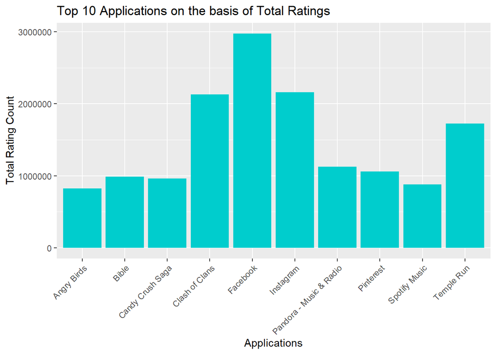

```r
sorted.data <- appleratings[order(-appleratings$rating_count_tot),]
top10 <-head(sorted.data,10)

#Top 10 Apps based on Total Rating

ggplot() + geom_bar(aes(y = top10$rating_count_tot, x = top10$track_name), data = top10,fill = "cyan3",stat="identity")+
  labs(x="Applications" , y="Total Rating Count")+
  theme(axis.text.x = element_text(angle = 45, hjust = 1))+
  ggtitle("Top 10 Applications on the basis of Total Ratings")
```

=======2) Do customers prefer paid applications or free applications?========== ======================Visualization for prefernce of user ======================

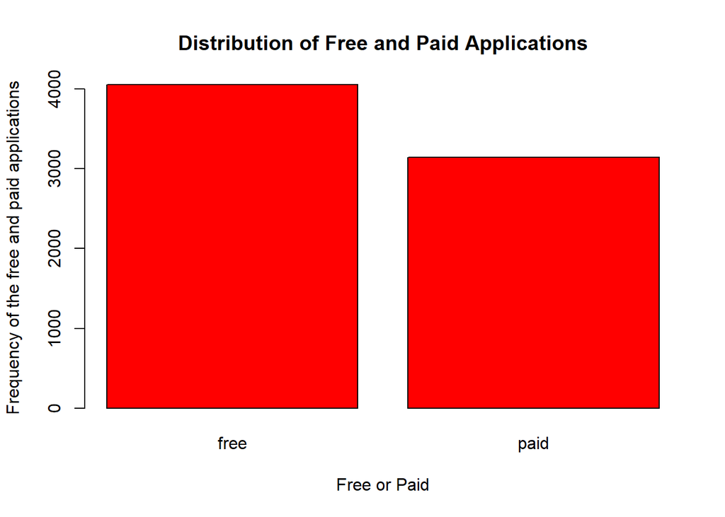

```r
appleratings$paid_or_free <- ifelse(appleratings$price>0,'paid','free')
counts <- table(appleratings$paid_or_free)
barplot(counts, main="Distribution of Free and Paid Applications",
        xlab="Free or Paid",
        ylab="Frequency of the free and paid applications",
        col="red")
```

============3) Which genre of applications is mostly used by the users?=======

==========Visualization for Top 10 genre of application used by user =======

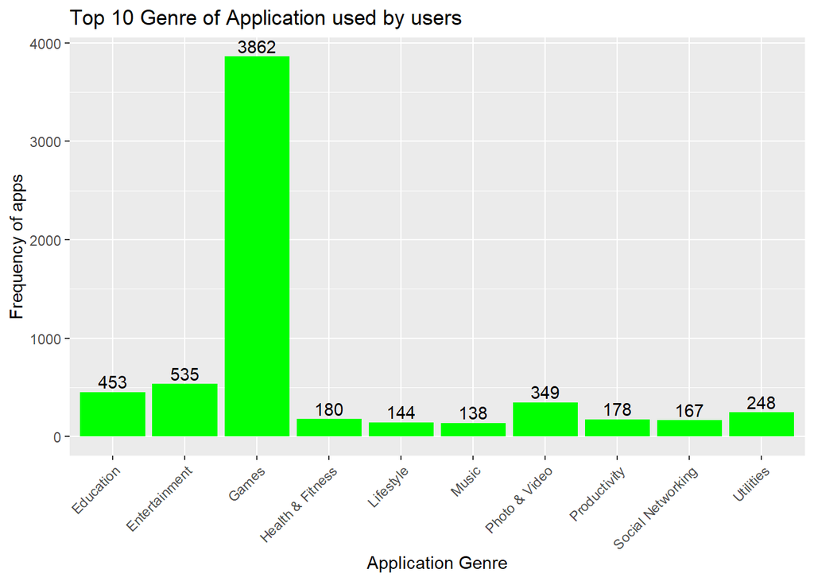

```r
#code for getting frequency of genre types
frequeny_genre = as.data.frame(table(appleratings$prime_genre))

sorted.data <- frequeny_genre[order(-frequeny_genre$Freq),]
top10 <-head(sorted.data,10)

ggplot(top10, aes(x = Var1, y = Freq)) +
  geom_bar(fill = "green", stat = "identity") +
  geom_text(aes(label = Freq), vjust = -0.3) +
  theme(axis.text.x = element_text(angle = 45, hjust = 1))+
  ggtitle("Top 10 Genre of Application used by users") +
  xlab("Application Genre")+
  ylab("Frequency of apps")
```

From the plot of Top 10 Genre of Application used by Users we can say that the applications with the genre Games is most popular among the customers. Game genre has the has the highest frequency of usage of 3862 followed by Entertainment, Education and Photo & Video genre.

===4) Does the price of the applications depend on the genre of the application?==

```r
appleratings<- read.csv("C:/Users/15714/Documents/GMU/OR-568/Final Project/data/AppleStore.csv")
price_genre=data.frame("Price","Genre")


magic_for(print, silent = TRUE)

for(i in unique(appleratings$prime_genre))
{
  print(i)
  newdata <- appleratings[ which(appleratings$prime_genre==i),]
  average_price=mean(newdata$price)
  average_price = round(average_price,2)
  print(average_price)
  price_genre=rbind(price_genre,list(average_price,i))

}
```

[output not shown]

[output cut: 82 more lines]

[output not shown]

```r
#creating data frame and retrieving the values from fr loop
price_genre=magic_result_as_dataframe()

#deleting the duplicate values from the dataframe
price_genre = subset(price_genre, !duplicated(subset(price_genre, select=-c(i))))
price_genre
```

```
##                    i               i.1 average_price
## 1              Games             Games          1.43
## 2       Productivity      Productivity          4.33
## 3            Weather           Weather          1.61
## 4           Shopping          Shopping          0.02
## 5          Reference         Reference          4.84
## 6            Finance           Finance          0.42
## 7              Music             Music          4.84
## 8          Utilities         Utilities          1.65
## 9             Travel            Travel          1.12
## 10 Social Networking Social Networking          0.34
## 11            Sports            Sports          0.95
## 12          Business          Business          5.12
## 13  Health & Fitness  Health & Fitness          1.92
## 14     Entertainment     Entertainment          0.89
## 15     Photo & Video     Photo & Video          1.47
## 16        Navigation        Navigation          4.12
## 17         Education         Education          4.03
## 18         Lifestyle         Lifestyle          0.89
## 19      Food & Drink      Food & Drink          1.55
## 20              News              News          0.52
## 21              Book              Book          1.79
## 22           Medical           Medical          8.78
## 23          Catalogs          Catalogs          0.80
```

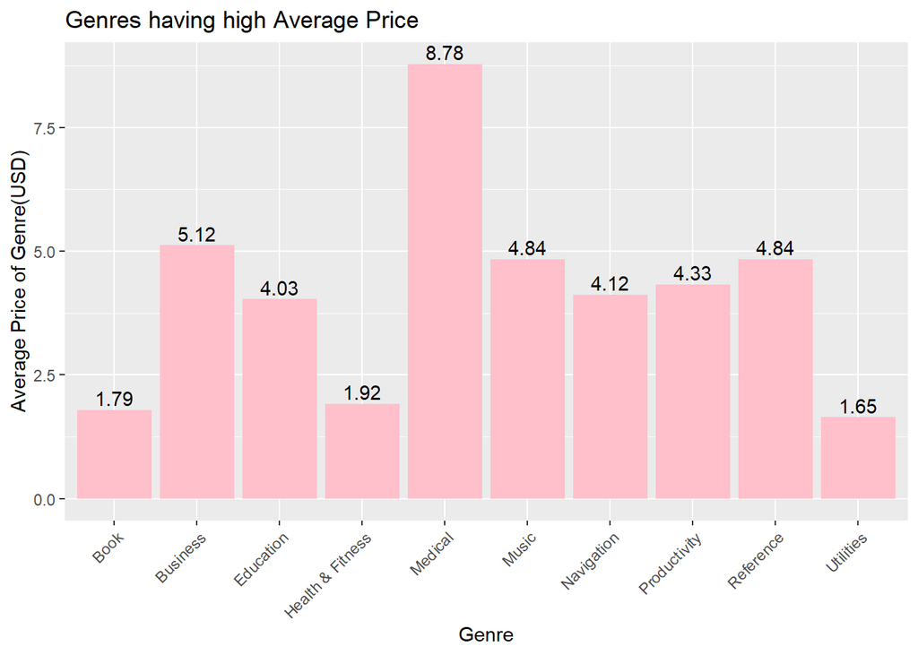

```r
sorted.data <- price_genre[order(-price_genre$average_price),]
top10_avg <-head(sorted.data,10)

#plotting the genre categories on x axis and average price on y-axis
ggplot(top10, aes(x = top10_avg$i, y = top10_avg$average_price)) +
  geom_bar(fill = "pink", stat = "identity") +
  geom_text(aes(label = top10_avg$average_price), vjust = -0.3) +
  theme(axis.text.x = element_text(angle = 45, hjust = 1)) +
  ggtitle("Genres having high Average Price") + xlab("Genre") + ylab("Average Price of Genre(USD)")
```

===5) Does the price of the applications increase with the size of the application? ===

====Variation of the price of the applications increase with the size of the application for user ratings=====

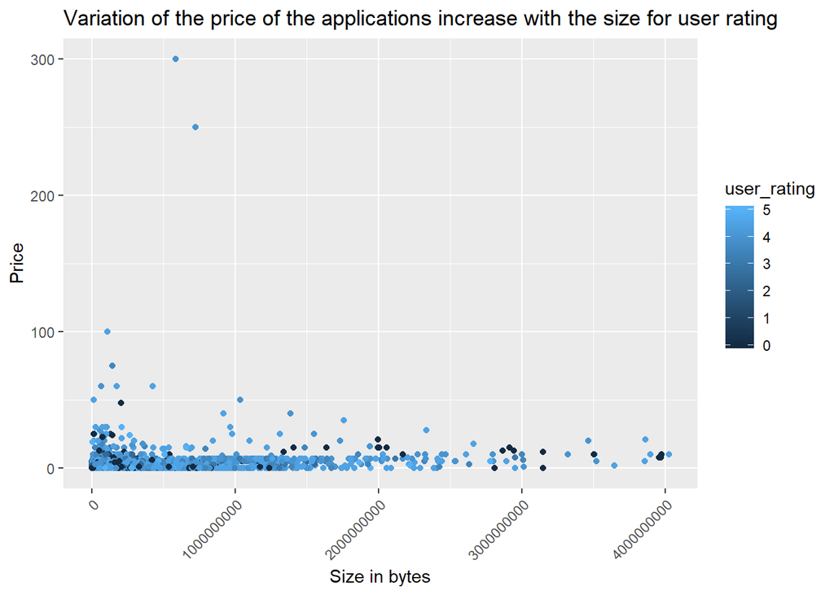

```r
ggplot(data = appleratings) +
  geom_point(mapping = aes(x = appleratings$size_bytes, y = appleratings$price, color = user_rating))+
  labs(x="Size in bytes" , y="Price")+
  theme(axis.text.x = element_text(angle = 45, hjust = 1))+
  ggtitle("Variation of the price of the applications increase with the size for user rating")
```

===================Hypothesis testing========================= Null Hypothesis H0 - The average user rating is equal to 3.5 Alternate Hypothesis H1 - The average user rating is not equal to 3.5

```r
appleratings = read.csv("C:/Users/15714/Documents/GMU/OR-568/Final Project/data/AppleStore.csv")
```

calculating mean for user_rating

```r
mean(appleratings$user_rating)
```

```
## [1] 3.526956
```

coverting ver variable into numeric

```r
appleratings$ver=as.numeric(as.integer(factor(appleratings$ver)))
```

calculating mean for ver variable

```r
mean(appleratings$ver)
```

```
## [1] 510.7578
```

one sample t-test for user_rating and ver variables

```r
t.test(appleratings$user_rating, mu=3.5)
```

```
##
##  One Sample t-test
##
## data:  appleratings$user_rating
## t = 1.5065, df = 7196, p-value = 0.132
## alternative hypothesis: true mean is not equal to 3.5
## 95 percent confidence interval:
##  3.491880 3.562031
## sample estimates:
## mean of x
##  3.526956
```

The p-value we got is 0.132 if p-value > 0.05 then we accept null hypothesis stating that Average User_rating is 3.5 and reject alternative hypothesis.

Null Hypothesis H0 : User rating is independent of the application version. Alternative Hypothesis H1 : User rating is dependent of the application version. Two sample t-test

```r
test2<-t.test(appleratings$user_rating,appleratings$ver,alternative="two.sided",mu=0,var.equal=F,conf.level=0.95)
test2
```

```
##
##  Welch Two Sample t-test
##
## data:  appleratings$user_rating and appleratings$ver
## t = -102.22, df = 7196.2, p-value < 0.00000000000000022
## alternative hypothesis: true difference in means is not equal to 0
## 95 percent confidence interval:
##  -516.9578 -497.5039
## sample estimates:
##  mean of x  mean of y
##   3.526956 510.757816
```

p-value we got in this hypothesis is less than 0.05, so we can reject null hypothesis which indicates that user rating and version are dependent on each other.

Null Hypothesis : The average price of application is equal to 1.5$ Null Hypothesis : The average price of application is is not equal to 1.5$ one sample t test for price of the app

```r
t.test(appleratings$price, mu=1.5, conf.level = 0.95)
```

```
##
##  One Sample t-test
##
## data:  appleratings$price
## t = 3.2901, df = 7196, p-value = 0.001006
## alternative hypothesis: true mean is not equal to 1.5
## 95 percent confidence interval:
##  1.591434 1.861002
## sample estimates:
## mean of x
##  1.726218
```

p-value we got in this hypothesis is less than 0.05, so we can reject null hypothesis which indicates that average price of application is not equal to 1.5$.

Null Hypothesis H0 : Average number of supported devices is equal to 30 Alternative Hypothesis H1 : Average number of supported devices is not equal to 30

one sample t-test for supp_devices

```r
t.test(appleratings$sup_devices.num, mu=30, conf.level = 0.95)
```

```
##
##  One Sample t-test
##
## data:  appleratings$sup_devices.num
## t = 167.09, df = 7196, p-value < 0.00000000000000022
## alternative hypothesis: true mean is not equal to 30
## 95 percent confidence interval:
##  37.27545 37.44819
## sample estimates:
## mean of x
##  37.36182
```

p-value we got in this hypothesis is less than 0.05, so we can reject null hypothesis which indicates that average number of supported devices is not equal to 30.

============Function to calculate Accuracies===================

```r
calculate_accuracy <- function(x){sum(diag(x)/(sum(rowSums(x)))) * 100}
```

==================Regression Algorithms===========

Data Cleaning

Read Data from the csv

```r
appleratings<- read.csv("C:/Users/15714/Documents/GMU/OR-568/Final Project/data/AppleStore.csv")
```

Taking Subset of the data

```r
appleratings <- subset( appleratings, select = -c(id,track_name,currency))
head(appleratings)
```

```
##   size_bytes price rating_count_tot rating_count_ver user_rating
## 1  100788224  3.99            21292               26         4.0
## 2  158578688  0.00           161065               26         4.0
## 3  100524032  0.00           188583             2822         3.5
## 4  128512000  0.00           262241              649         4.0
## 5   92774400  0.00           985920             5320         4.5
## 6   10485713  0.99             8253             5516         4.0
##   user_rating_ver    ver cont_rating  prime_genre sup_devices.num
## 1             4.5  6.3.5          4+        Games              38
## 2             3.5  8.2.2          4+ Productivity              37
## 3             4.5  5.0.0          4+      Weather              37
## 4             4.5 5.10.0         12+     Shopping              37
## 5             5.0  7.5.1          4+    Reference              37
## 6             4.0    1.8          4+        Games              47
##   ipadSc_urls.num lang.num vpp_lic
## 1               5       10       1
## 2               5       23       1
## 3               5        3       1
## 4               5        9       1
## 5               5       45       1
## 6               5        1       1
```

Converting the columns to factors

```r
appleratings$prime_genre=as.numeric(as.integer(factor(appleratings$prime_genre)))
appleratings$cont_rating=as.numeric(as.integer(factor(appleratings$cont_rating)))
appleratings$ver=as.numeric(as.integer(factor(appleratings$ver)))
```

Splitting the data into 70-30 ratio

```r
index <- sample(2, nrow(appleratings),replace = TRUE, prob = c(0.7,0.3))
trainapp <- appleratings[index==1,]
head(trainapp)
```

```
##   size_bytes price rating_count_tot rating_count_ver user_rating
## 1  100788224  3.99            21292               26         4.0
## 2  158578688  0.00           161065               26         4.0
## 3  100524032  0.00           188583             2822         3.5
## 4  128512000  0.00           262241              649         4.0
## 7  227795968  0.00           119487              879         4.0
## 8  130242560  0.00          1126879             3594         4.0
##   user_rating_ver  ver cont_rating prime_genre sup_devices.num ipadSc_urls.num
## 1             4.5 1338           3           8              38               5
## 2             3.5 1472           3          16              37               5
## 3             4.5 1174           3          23              37               5
## 4             4.5 1199           1          18              37               5
## 7             4.5 1319           3           6              37               0
## 8             4.5 1480           1          12              37               4
##   lang.num vpp_lic
## 1       10       1
## 2       23       1
## 3        3       1
## 4        9       1
## 7       19       1
## 8        1       1
```

```r
testapp <- appleratings[index==2,]
head(testapp)
```

```
##    size_bytes price rating_count_tot rating_count_ver user_rating
## 5    92774400  0.00           985920             5320         4.5
## 6    10485713  0.99             8253             5516         4.0
## 15   55153664  4.99             6340              668         4.5
## 18  167407616  0.00           223885             3726         4.0
## 21   70707916  1.99             2929              966         4.5
## 23  130583552  0.00           137951              131         4.0
##    user_rating_ver  ver cont_rating prime_genre sup_devices.num ipadSc_urls.num
## 5              5.0 1431           3          17              37               5
## 6              4.0  443           3           8              47               5
## 15             4.5 1034           3           8              38               5
## 18             4.5  536           1          21              37               5
## 21             4.5  932           3          17              43               0
## 23             4.5 1379           3          20              37               2
##    lang.num vpp_lic
## 5        45       1
## 6         1       1
## 15        2       1
## 18       18       1
## 21        2       1
## 23        6       1
```

===========Linear Regression Model=============

Linear Regression for user rating

Fitting regression model on the data

```r
linearRegression=lm(user_rating ~.,data=trainapp)
```

extracting the model summary

```r
summary(linearRegression)
```

```
##
## Call:
## lm(formula = user_rating ~ ., data = trainapp)
##
## Residuals:
##     Min      1Q  Median      3Q     Max
## -3.4766 -0.4667  0.0367  0.3341  3.8328
##
## Coefficients:
##                           Estimate        Std. Error t value
## (Intercept)       0.72562881511165  0.22517186159162   3.223
## size_bytes        0.00000000005896  0.00000000003980   1.481
## price             0.00505308592461  0.00263260373203   1.919
## rating_count_tot -0.00000005642250  0.00000016565549  -0.341
## rating_count_ver  0.00000437362153  0.00000335710720   1.303
## user_rating_ver   0.62576290126101  0.00775334968787  80.709
## ver               0.00042357653130  0.00003378004947  12.539
## cont_rating       0.01323799976379  0.01502584141359   0.881
## prime_genre       0.00086407688721  0.00289636438502   0.298
## sup_devices.num  -0.00313504774559  0.00366114074188  -0.856
## ipadSc_urls.num   0.05203588378780  0.00715158175646   7.276
## lang.num          0.00357915318483  0.00177492428681   2.017
## vpp_lic           0.39069314934181  0.15683783946751   2.491
##                              Pr(>|t|)
## (Intercept)                   0.00128 **
## size_bytes                    0.13859
## price                         0.05499 .
## rating_count_tot              0.73342
## rating_count_ver              0.19270
## user_rating_ver  < 0.0000000000000002 ***
## ver              < 0.0000000000000002 ***
## cont_rating                   0.37835
## prime_genre                   0.76546
## sup_devices.num               0.39187
## ipadSc_urls.num     0.000000000000396 ***
## lang.num                      0.04380 *
## vpp_lic                       0.01277 *
## ---
## Signif. codes:  0 '***' 0.001 '**' 0.01 '*' 0.05 '.' 0.1 ' ' 1
##
## Residual standard error: 0.9406 on 5063 degrees of freedom
## Multiple R-squared:  0.6165, Adjusted R-squared:  0.6156
## F-statistic: 678.2 on 12 and 5063 DF,  p-value: < 0.00000000000000022
```

Predicting the ratings using the test data

```r
predictionforlm<-predict(linearRegression,testapp)
```

Forming a dataframe containing actual and predicted values.

```r
actuals_predslm <- data.frame(cbind(ActualRating=testapp$user_rating, PredictedRating=predictionforlm))
print(actuals_predslm)
```

```
##      ActualRating PredictedRating
## 5             4.5       5.1840321
## 6             4.0       3.9993360
## 15            4.5       4.5960964
## 18            4.0       4.4128177
## 21            4.5       4.2720673
## 23            4.0       4.5834013
## 28            3.5       4.7559965
## 31            3.5       4.7082043
## 37            3.5       2.9329307
## 42            3.0       4.4291744
## 50            4.0       5.0344440
## 51            4.0       4.4266417
## 52            3.0       4.7827637
## 54            3.5       4.6245072
```

[output cut: 2107 more lines]

ploting the actual and the predicted values.

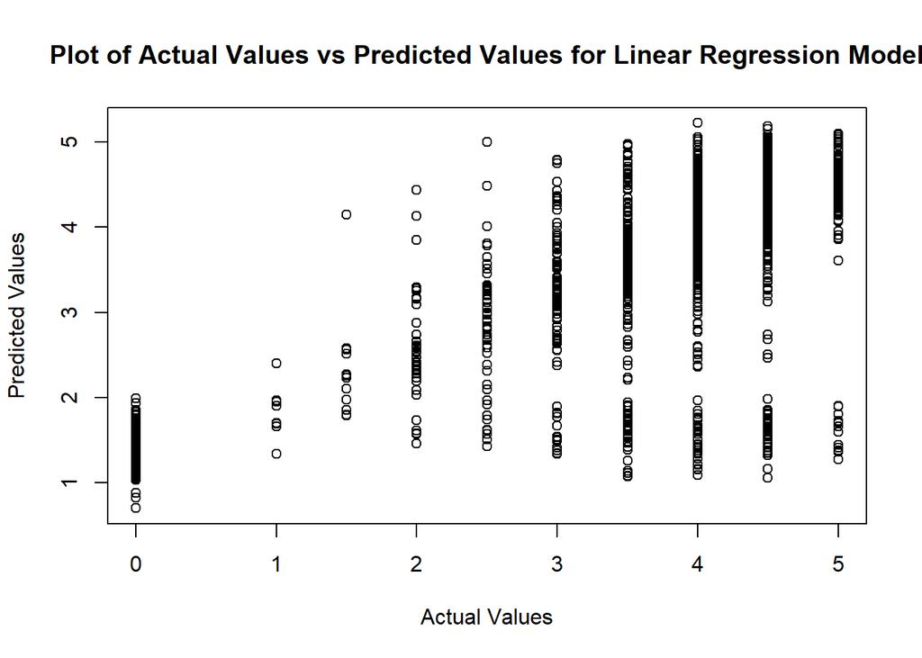

```r
plot((testapp$user_rating), predictionforlm,xlab="Actual Values",ylab="Predicted Values",
     main="Plot of Actual Values vs Predicted Values for Linear Regression Model")
```

===========Support Vector Machine ============

======= SVM for the user ratings===========

Fitting the SVM model

```r
userrating_svm <- svm(user_rating ~., data=trainapp)
```

summary of the model

```r
summary(userrating_svm)
```

```
##
## Call:
## svm(formula = user_rating ~ ., data = trainapp)
##
##
## Parameters:
##    SVM-Type:  eps-regression
##  SVM-Kernel:  radial
##        cost:  1
##       gamma:  0.08333333
##     epsilon:  0.1
##
##
## Number of Support Vectors:  3213
```

predictions on the testing data

```r
predictionsvm_userrating <- predict(userrating_svm, testapp)
```

forming dataframe for the actual and the predicted values

```r
actuals_predssvm <- data.frame(cbind(ActualRating=testapp$user_rating, PredictedRating=predictionsvm_userrating))
print(actuals_predssvm)
```

```
##      ActualRating PredictedRating
## 5             4.5    3.9811389659
## 6             4.0    4.1608752903
## 15            4.5    4.4457070109
## 18            4.0    4.3953291464
## 21            4.5    4.5018700428
## 23            4.0    4.0475786066
## 28            3.5    4.5815267684
## 31            3.5    4.2872302540
## 37            3.5    2.6447882587
## 42            3.0    4.2057133911
## 50            4.0    4.4746226969
## 51            4.0    4.3460300140
## 52            3.0    4.5115353581
## 54            3.5    3.7354073042
```

[output cut: 2107 more lines]

ploting the actual and the predicted values.

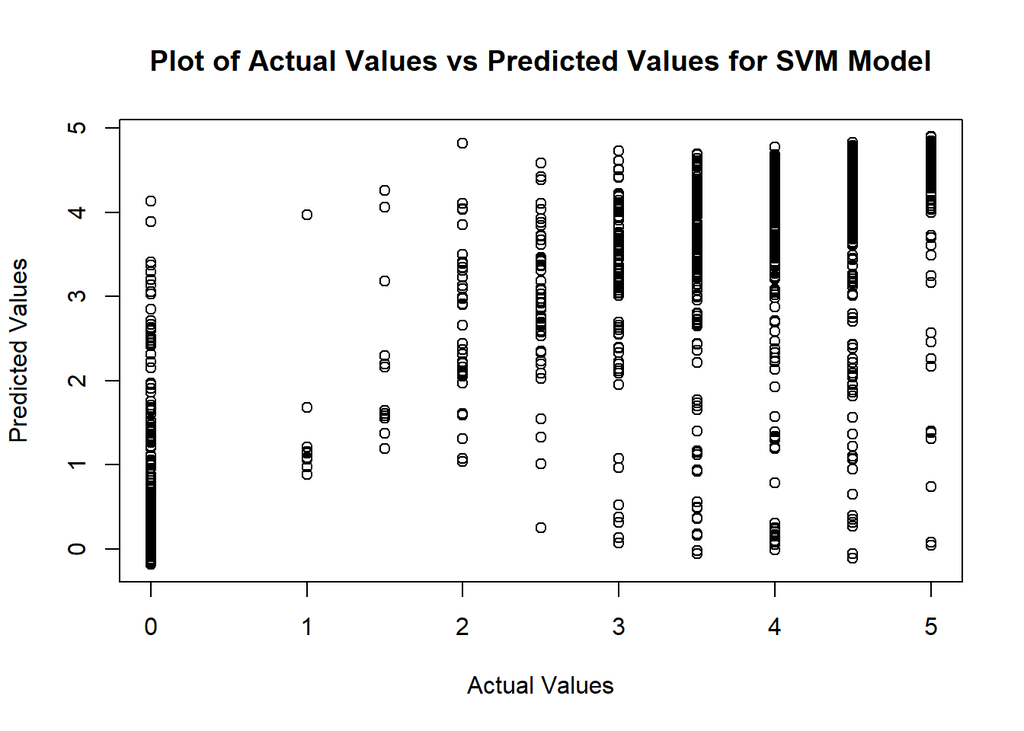

```r
plot((testapp$user_rating), predictionsvm_userrating,xlab="Actual Values",ylab="Predicted Values",
     main="Plot of Actual Values vs Predicted Values for SVM Model")
```

=============Random Regression forest Algorithm============

fitting the model

```r
regressor = randomForest(as.factor(user_rating) ~.,
                         data = trainapp,ntree = 500, mtry = 3, nPerm = 4, nodesize = 2,replace=T)
```

Variable importance plot

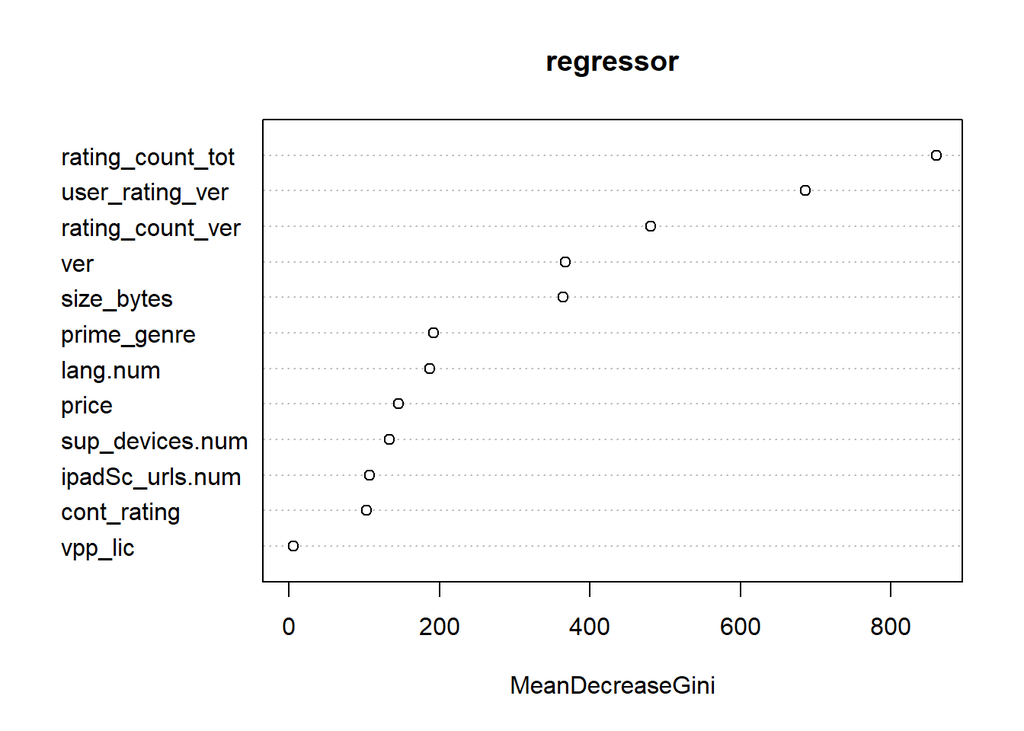

```r
varImpPlot(regressor)
```

```r
importance(regressor)
```

```
##                  MeanDecreaseGini
## size_bytes             364.322601
## price                  145.730979
## rating_count_tot       860.726945
## rating_count_ver       481.187781
## user_rating_ver        686.717931
## ver                    367.727835
## cont_rating            103.377122
## prime_genre            191.880104
## sup_devices.num        133.529026
## ipadSc_urls.num        107.121000
## lang.num               186.611953
## vpp_lic                  6.214987
```

VarImp plot shows that rating_count_tot ,user_rating_ver , rating_count_ver ,ver and size_bytes are the best predictors for the model.

Prediction on test data

```r
predict_regressiontree=predict(regressor,testapp,type ="class")
confmatrix_svn_genre=table(predict_regressiontree,as.factor(testapp$user_rating))
calculate_accuracy(confmatrix_svn_genre)
```

```
## [1] 61.81047
```

================Classification Algorithms=========

Data Cleaning

Read Data from the csv

```r
appleratings_clfy<- read.csv("C:/Users/15714/Documents/GMU/OR-568/Final Project/data/AppleStore.csv")
```

Taking Subset of the data

```r
appleratings_clfy <- subset( appleratings_clfy, select = -c(id,track_name,currency))
head(appleratings_clfy)
```

```
##   size_bytes price rating_count_tot rating_count_ver user_rating
## 1  100788224  3.99            21292               26         4.0
## 2  158578688  0.00           161065               26         4.0
## 3  100524032  0.00           188583             2822         3.5
## 4  128512000  0.00           262241              649         4.0
## 5   92774400  0.00           985920             5320         4.5
## 6   10485713  0.99             8253             5516         4.0
##   user_rating_ver    ver cont_rating  prime_genre sup_devices.num
## 1             4.5  6.3.5          4+        Games              38
## 2             3.5  8.2.2          4+ Productivity              37
## 3             4.5  5.0.0          4+      Weather              37
## 4             4.5 5.10.0         12+     Shopping              37
## 5             5.0  7.5.1          4+    Reference              37
## 6             4.0    1.8          4+        Games              47
##   ipadSc_urls.num lang.num vpp_lic
## 1               5       10       1
## 2               5       23       1
## 3               5        3       1
## 4               5        9       1
## 5               5       45       1
## 6               5        1       1
```

Converting the columns to factors

```r
appleratings_clfy$cont_rating=as.numeric(as.integer(factor(appleratings_clfy$cont_rating)))
appleratings_clfy$ver=as.numeric(as.integer(factor(appleratings_clfy$ver)))
```

Splitting the data into 70-30 ratio

```r
index <- sample(2, nrow(appleratings_clfy),replace = TRUE, prob = c(0.7,0.3))
trainapp_clfy <- appleratings_clfy[index==1,]
head(trainapp_clfy)
```

```
##    size_bytes price rating_count_tot rating_count_ver user_rating
## 2   158578688  0.00           161065               26         4.0
## 4   128512000  0.00           262241              649         4.0
## 5    92774400  0.00           985920             5320         4.5
## 6    10485713  0.99             8253             5516         4.0
## 10   70023168  3.99             7885               40         4.0
## 11   49618944  4.99            76720             4017         4.5
##    user_rating_ver  ver cont_rating  prime_genre sup_devices.num
## 2              3.5 1472           3 Productivity              37
## 4              4.5 1199           1     Shopping              37
## 5              5.0 1431           3    Reference              37
## 6              4.0  443           3        Games              47
## 10             4.0 1036           3        Games              38
## 11             4.5 1064           3        Games              38
##    ipadSc_urls.num lang.num vpp_lic
## 2                5       23       1
## 4                5        9       1
## 5                5       45       1
## 6                5        1       1
## 10               0       10       1
## 11               4       11       1
```

```r
testapp_clfy <- appleratings_clfy[index==2,]
head(testapp_clfy)
```

```
##    size_bytes price rating_count_tot rating_count_ver user_rating
## 1   100788224  3.99            21292               26         4.0
## 3   100524032  0.00           188583             2822         3.5
## 7   227795968  0.00           119487              879         4.0
## 8   130242560  0.00          1126879             3594         4.0
## 9    49250304  9.99             1117                4         4.5
## 14  160925696  0.00           119773             2336         3.5
##    user_rating_ver  ver cont_rating prime_genre sup_devices.num ipadSc_urls.num
## 1              4.5 1338           3       Games              38               5
## 3              4.5 1174           3     Weather              37               5
## 7              4.5 1319           3     Finance              37               0
## 8              4.5 1480           1       Music              37               4
## 9              5.0  979           3   Utilities              37               5
## 14             4.5 1422           3     Finance              37               0
##    lang.num vpp_lic
## 1        10       1
## 3         3       1
## 7        19       1
## 8         1       1
## 9         1       1
## 14        2       1
```

===========Raandom Forest Classifier========================

Random forest for genre

```r
randomforest_genre1 <- randomForest(prime_genre ~ ., data = trainapp_clfy, ntree = 500, mtry=6,importance = TRUE)
randomforest_genre1
```

```
##
## Call:
##  randomForest(formula = prime_genre ~ ., data = trainapp_clfy,      ntree = 500, mtry = 6, importance = TRUE)
##                Type of random forest: classification
##                      Number of trees: 500
## No. of variables tried at each split: 6
##
##         OOB estimate of  error rate: 39.42%
## Confusion matrix:
##                   Book Business Catalogs Education Entertainment Finance
## Book                25        0        0         4             6       0
## Business             1        0        0         1             0       0
## Catalogs             1        0        0         0             0       1
## Education            2        1        0        94            12       2
## Entertainment        3        0        0        11           119       2
## Finance              1        0        1         1             8      18
## Food & Drink         0        0        0         3             6       2
## Games                6        1        0        21            38       6
## Health & Fitness     0        0        2         4             9       1
## Lifestyle            0        0        0         5            24       4
## Medical              0        0        0         0             3       2
## Music                1        0        0         2            12       0
## Navigation           1        0        1         3             3       2
## News                 0        0        0         0            13       1
## Photo & Video        2        0        0         6            23       1
## Productivity         0        0        0         5             4       0
## Reference            0        0        0         5             6       0
## Shopping             0        0        0         2            17       7
## Social Networking    2        0        0         2            24       4
## Sports               0        0        0         4            20       2
## Travel               0        0        0         4             4       1
## Utilities            0        0        0        12            31       1
## Weather              0        0        0         3             4       0
##                   Food & Drink Games Health & Fitness Lifestyle Medical Music
## Book                         0    33                0         1       1     0
## Business                     0    11                1         1       0     1
## Catalogs                     0     2                0         1       0     0
## Education                    2   162                1         2       0     0
## Entertainment                0   171                4         8       0     0
## Finance                      0    16                1         3       0     0
```

[output cut: 50 more lines]

```
## Health & Fitness                  4      1      0         7       0  0.90839695
## Lifestyle                         5      1      1         6       2  0.95145631
## Medical                           0      0      1         1       0  0.92857143
## Music                             3      1      0         6       1  0.90909091
## Navigation                        2      0      0         3       1  0.97435897
## News                              3      1      0         2       2  0.92857143
## Photo & Video                     4      2      0        11       2  0.71008403
## Productivity                      2      2      1         8       0  0.71900826
## Reference                         0      0      1         2       0  0.95454545
## Shopping                          4      1      2         3       0  0.85555556
## Social Networking                13      4      3         4       1  0.88888889
## Sports                            2      7      1         4       0  0.91666667
## Travel                            4      0      3         2       0  0.95000000
## Utilities                         4      2      1        26       2  0.84705882
## Weather                           1      0      0         4       4  0.91836735
```

Prediction on the testing data

```r
pred_randonforestgenre1 <- predict(randomforest_genre1,testapp_clfy , type = "class")
confmatrix_randomf_genre=table(pred_randonforestgenre1,testapp_clfy$prime_genre)
print(confmatrix_randomf_genre)
```

```
##
## pred_randonforestgenre1 Book Business Catalogs Education Entertainment Finance
##       Book                13        1        0         1             4       0
##       Business             0        0        0         0             0       0
##       Catalogs             0        0        0         0             0       0
##       Education            1        1        1        53             1       0
##       Entertainment        1        0        0         7            43       5
##       Finance              1        0        0         0             3       7
##       Food & Drink         0        0        0         0             1       0
##       Games               16        7        2        64            67       3
##       Health & Fitness     0        3        0         0             1       1
##       Lifestyle            0        0        0         0             1       2
##       Medical              0        0        0         0             0       0
##       Music                0        1        0         2             1       0
##       Navigation           0        0        0         0             0       0
##       News                 0        0        0         0             1       1
##       Photo & Video        0        4        0         4             7       0
##       Productivity         1        2        0         4             1       1
##       Reference            0        0        0         1             0       0
##       Shopping             0        1        0         0             3       4
##       Social Networking    1        0        0         0             4       2
##       Sports               0        0        0         1             1       0
##       Travel               0        0        0         0             2       1
##       Utilities            0        0        0         3             9       4
##       Weather              0        0        0         0             0       1
##
## pred_randonforestgenre1 Food & Drink Games Health & Fitness Lifestyle Medical
##       Book                         0     2                0         0       0
##       Business                     0     1                0         0       0
##       Catalogs                     0     0                0         0       0
##       Education                    0     8                8         1       1
##       Entertainment                2    23                4         5       0
##       Finance                      3     5                0         1       0
##       Food & Drink                 0     0                0         1       0
##       Games                        7  1038               15        15       5
##       Health & Fitness             0     2               13         1       1
##       Lifestyle                    1     0                0         3       0
##       Medical                      0     0                0         0       1
##       Music                        0     1                1         0       1
##       Navigation                   1     0                0         0       0
```

[output cut: 70 more lines]

```
##       Health & Fitness          4       2
##       Lifestyle                 0       0
##       Medical                   0       0
##       Music                     0       0
##       Navigation                0       0
##       News                      0       0
##       Photo & Video             9       3
##       Productivity              2       0
##       Reference                 0       0
##       Shopping                  1       0
##       Social Networking         5       1
##       Sports                    1       0
##       Travel                    1       0
##       Utilities                 9       0
##       Weather                   0       1
```

```r
calculate_accuracy(confmatrix_randomf_genre)
```

```
## [1] 58.94988
```

```r
svm_genre <- svm(prime_genre ~ ., data=trainapp_clfy,
                 method="C-classification", kernal="radial",
                 gamma=0.1, cost=10)
summary(svm_genre)
```

```
##
## Call:
## svm(formula = prime_genre ~ ., data = trainapp_clfy, method = "C-classification",
##     kernal = "radial", gamma = 0.1, cost = 10)
##
##
## Parameters:
##    SVM-Type:  C-classification
##  SVM-Kernel:  radial
##        cost:  10
##
## Number of Support Vectors:  3351
##
##  ( 119 90 44 1029 170 60 117 99 84 131 382 234 39 49 37 306 72 45 42 103 78 14 7 )
##
##
## Number of Classes:  23
##
## Levels:
##  Book Business Catalogs Education Entertainment Finance Food & Drink Games Health & Fitness Lifestyle Medical Music Navigation News Photo & Video Productivity Reference Shopping Social Networking Sports Travel Utilities Weather
```

```r
prediction_svm <- predict(svm_genre, testapp_clfy)
confmatrix_svn_genre=table(prediction_svm,testapp_clfy$prime_genre)
print(confmatrix_svn_genre)
```

```
##
## prediction_svm      Book Business Catalogs Education Entertainment Finance
##   Book                 4        0        0         0             0       0
##   Business             0        1        0         0             0       0
##   Catalogs             0        0        0         0             0       0
##   Education            1        1        0        38             1       2
##   Entertainment        2        0        0         4            37       6
##   Finance              1        0        0         0             4       6
##   Food & Drink         0        0        0         0             1       0
##   Games               24       12        3        82            87       9
##   Health & Fitness     0        0        0         0             1       0
##   Lifestyle            0        1        0         0             1       0
##   Medical              0        0        0         0             0       0
##   Music                0        1        0         0             0       0
##   Navigation           0        0        0         0             0       0
##   News                 0        0        0         0             0       0
##   Photo & Video        1        2        0         4             4       0
##   Productivity         1        2        0         3             1       0
##   Reference            0        0        0         5             0       0
##   Shopping             0        0        0         0             4       2
##   Social Networking    0        0        0         0             5       3
##   Sports               0        0        0         0             0       0
##   Travel               0        0        0         1             0       1
##   Utilities            0        0        0         3             4       2
##   Weather              0        0        0         0             0       1
##
## prediction_svm      Food & Drink Games Health & Fitness Lifestyle Medical Music
##   Book                         1     0                0         0       0     0
##   Business                     0     0                0         0       0     0
##   Catalogs                     0     0                0         0       0     0
##   Education                    0     3                1         1       0     1
##   Entertainment                1    14                2         7       0     3
##   Finance                      1     3                0         2       0     1
##   Food & Drink                 0     1                0         0       0     0
##   Games                        7  1056               25        18       5    24
##   Health & Fitness             0     0                5         2       1     0
##   Lifestyle                    0     1                1         0       0     0
##   Medical                      0     0                0         0       2     0
##   Music                        0     0                0         0       0     1
##   Navigation                   0     0                1         0       0     0
```

[output cut: 45 more lines]

```
##   Health & Fitness         1                 0      0      0         0       1
##   Lifestyle                0                 2      1      0         0       0
##   Medical                  0                 0      0      0         0       0
##   Music                    0                 0      0      0         0       0
##   Navigation               0                 0      0      0         0       0
##   News                     0                 1      0      0         0       0
##   Photo & Video            1                 4      4      3         3       2
##   Productivity             0                 2      0      0         0       0
##   Reference                0                 0      0      0         1       0
##   Shopping                 8                 0      0      1         4       0
##   Social Networking        2                 7      1      0         4       0
##   Sports                   2                 0      1      0         0       0
##   Travel                   0                 1      1      0         1       0
##   Utilities                1                 1      0      1         6       1
##   Weather                  0                 0      0      0         0       1
```

```r
calculate_accuracy(confmatrix_svn_genre)
```

```
## [1] 57.3747
```

```r
naive_bayes_classifier <- naive_bayes(prime_genre ~ .,data=trainapp_clfy, usekernel=T)
summary(naive_bayes_classifier)
```

```
##
## ================================== Naive Bayes ==================================
##
## - Call: naive_bayes.formula(formula = prime_genre ~ ., data = trainapp_clfy,      usekernel = T)
## - Laplace: 0
## - Classes: 23
## - Samples: 5102
## - Features: 12
## - Conditional distributions:
##     - KDE: 12
## - Prior probabilities:
##     - Book: 0.0153
##     - Business: 0.0073
##     - Catalogs: 0.0014
##     - Education: 0.0613
##     - Entertainment: 0.0755
##     - Finance: 0.0141
##     - Food & Drink: 0.0088
##     - Games: 0.5417
##     - Health & Fitness: 0.0257
##     - Lifestyle: 0.0202
##     - Medical: 0.0027
##     - Music: 0.0194
##     - Navigation: 0.0076
##     - News: 0.0082
##     - Photo & Video: 0.0466
##     - Productivity: 0.0237
##     - Reference: 0.0086
##     - Shopping: 0.0176
##     - Social Networking: 0.0229
##     - Sports: 0.0165
##     - Travel: 0.0118
##     - Utilities: 0.0333
##     - Weather: 0.0096
##
## ---------------------------------------------------------------------------------
```

```r
naive_prediction_test<-predict(naive_bayes_classifier,testapp_clfy)
confmatrix_nb_genre=table(naive_prediction_test,testapp_clfy$prime_genre)
print(confmatrix_nb_genre)
```

```
##
## naive_prediction_test Book Business Catalogs Education Entertainment Finance
##     Book                 2        0        0         4             9       0
##     Business             0        0        0         0             0       0
##     Catalogs             0        0        0         0             0       0
##     Education            0        1        0         7             1       0
##     Entertainment        2        1        0         5            23       8
##     Finance              0        0        0         0             0       1
##     Food & Drink         0        0        0         0             0       0
##     Games               26       18        3       122           112      23
##     Health & Fitness     0        0        0         0             1       0
##     Lifestyle            0        0        0         0             1       0
##     Medical              0        0        0         0             0       0
##     Music                0        0        0         0             0       0
##     Navigation           3        0        0         2             0       0
##     News                 0        0        0         0             0       0
##     Photo & Video        0        0        0         0             0       0
##     Productivity         0        0        0         0             0       0
##     Reference            0        0        0         0             0       0
##     Shopping             0        0        0         0             1       0
##     Social Networking    0        0        0         0             1       0
##     Sports               0        0        0         0             0       0
##     Travel               1        0        0         0             1       0
##     Utilities            0        0        0         0             0       0
##     Weather              0        0        0         0             0       0
##
## naive_prediction_test Food & Drink Games Health & Fitness Lifestyle Medical
##     Book                         1     7                3         1       0
##     Business                     0     0                0         0       0
##     Catalogs                     0     0                0         0       0
##     Education                    0     6                1         0       0
##     Entertainment                2    23                5         7       0
##     Finance                      0     0                0         1       0
##     Food & Drink                 0     1                0         0       0
##     Games                       13  1022               38        32       7
##     Health & Fitness             0     4                0         0       0
##     Lifestyle                    0     2                0         0       0
##     Medical                      0     1                0         0       0
##     Music                        0     0                0         0       0
##     Navigation                   0    26                0         0       1
```

[output cut: 70 more lines]

```
##     Health & Fitness          0       0
##     Lifestyle                 0       0
##     Medical                   0       0
##     Music                     0       0
##     Navigation                0       0
##     News                      0       0
##     Photo & Video             0       0
##     Productivity              0       0
##     Reference                 0       0
##     Shopping                  0       0
##     Social Networking         2       0
##     Sports                    0       0
##     Travel                    0       1
##     Utilities                 0       0
##     Weather                   0       0
```

```r
calculate_accuracy(confmatrix_nb_genre)
```

```
## [1] 50.358
```

The Random forest has performed best on the testing data among all the classification models and naive bayes classification algorithm has the least accuracy.